# Portfolio Project: Evaluation and Comparison of Algorithm Effectiveness

Perkins Offi

15 April 2022

## Introduction.

The use of machine learning algorithms in the world of business has evolved at lightning speed over the last few years. Algorithms have been designed to predict and execute all sorts of business aspects. Most times, several algorithms are proposed to solve the same problem and the best is usually chosen after appropriate evaluation of relative performances. In this project, a comparison of the performance/effectiveness of two such algorithms will be carried out.

The purpose of the study for which the data has been gathered is to evaluate the effectiveness of the new algorithm, whose accuracies are given by variable model2, relative to the performance of the benchmark algorithm, whose accuracies are given by variable model1.

### Loading the dataset and necessary libraries.

The dataset which is in csv format was loaded using the read.csv function and saved in a variable called ‘data’.

```r
#Set working directory
setwd("C:/Users/perki/Desktop/RGU/Data Science/Coursework/CMM507 Coursework 2")

#Load datasets
data = read.csv("transactions.csv", header = T, stringsAsFactors = T)
```

```r
library(ggplot2)
library(dplyr)
```

## Section 1: Visualisations and Summary Statistics.

### 1.1

#### Histogram plot showing the distribution of the values for model2.

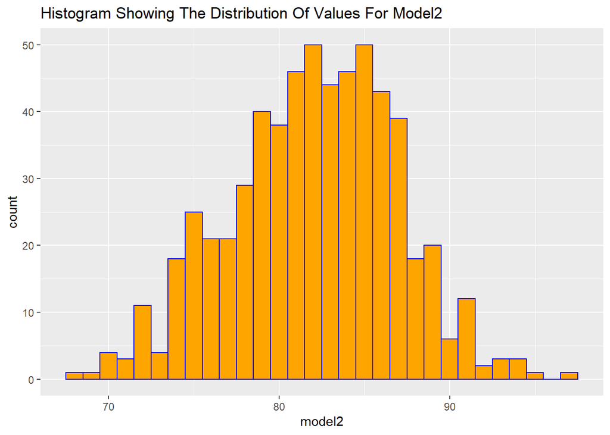

```r
plot = ggplot(data = data, aes(x=model2))
plot = plot + geom_histogram(fill = 'orange', color = 'blue', binwidth = 1) + labs(title = "Histogram Showing The Distribution Of Values For Model2")
plot
```

#### Mean and median values for model2.

```r
cat("Mean value for model2:", mean(data$model2), "\n")
```

```
## Mean value for model2: 82.07133
```

```r
cat("Median value for model2:", median(data$model2))
```

```
## Median value for model2: 82.3
```

#### Commenting on whether model2 shows a normal distribution.

Confirming normality using the Shapiro-Wilk normality test.

```r
shapiro.test(data$model2)
```

```
##
##  Shapiro-Wilk normality test
##
## data:  data$model2
## W = 0.99547, p-value = 0.07775
```

COMMENT: The histogram shows a normal distribution of model2 and this is confirmed by the Shapiro-Wilk normality test, with a p-value > 0.05 (0.07775) suggesting that the distribution of model2 is normal.

### 1.2

#### Histogram plot showing the distribution of the values for value.

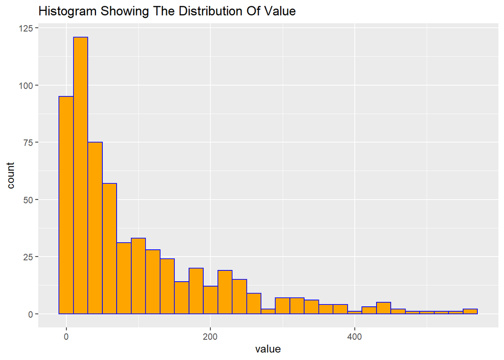

```r
plot3 = ggplot(data = data, aes(x=value))
plot3 = plot3 + geom_histogram(fill = 'orange', color = 'blue', binwidth = 20) + labs(title = "Histogram Showing The Distribution Of Value")
plot3
```

#### Mean and median values for value.

```r
cat("Mean value for value:", mean(data$value), "\n")
```

```
## Mean value for value: 96.24213
```

```r
cat("Median value for value:", median(data$value))
```

```
## Median value for value: 51.985
```

#### Commenting on whether value shows a normal distribution.

Confirming normality using the Shapiro-Wilk normality test.

```r
shapiro.test(data$value)
```

```
##
##  Shapiro-Wilk normality test
##
## data:  data$value
## W = 0.7954, p-value < 2.2e-16
```

COMMENT: The histogram and the Shapiro-Wilk test confirms that the distribution of value is NOT normal with a p-value < 0.05 (2.2e-16).

### 1.3

#### Boxplot of the value variable split by the recipient category.

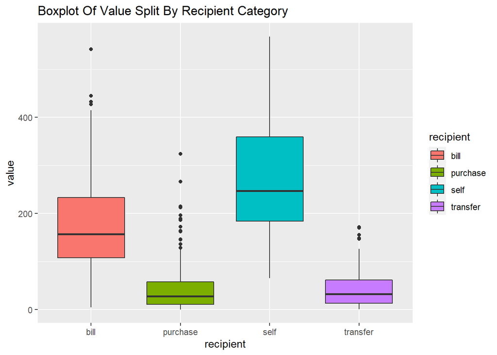

```r
bxplot = ggplot(data = data, aes(x=recipient, y=value, fill=recipient))
bxplot = bxplot + geom_boxplot() + labs(title = "Boxplot Of Value Split By Recipient Category")
bxplot
```

#### Mean and Standard Deviation of value for each type of recipient.

```r
summarise(group_by(data, recipient), Means = mean(value), StDev = sd(value))
```

```
## # A tibble: 4 x 3
##   recipient Means StDev
##   <fct>     <dbl> <dbl>
## 1 bill      178.  103.
## 2 purchase   42.4  46.6
## 3 self      278.  135.
## 4 transfer   43.2  41.5
```

#### Comment critically on the dependence of value on the recipient type.

COMMENT: From the boxplot above, it is observed that apart from the purchase and transfer categories of recipient, all middle 50% of the values for each category are at different locations. The suggests that recipient type has an effect on value.

### 1.4

#### Scatterplot of time against value with the points colour coded according to the device.

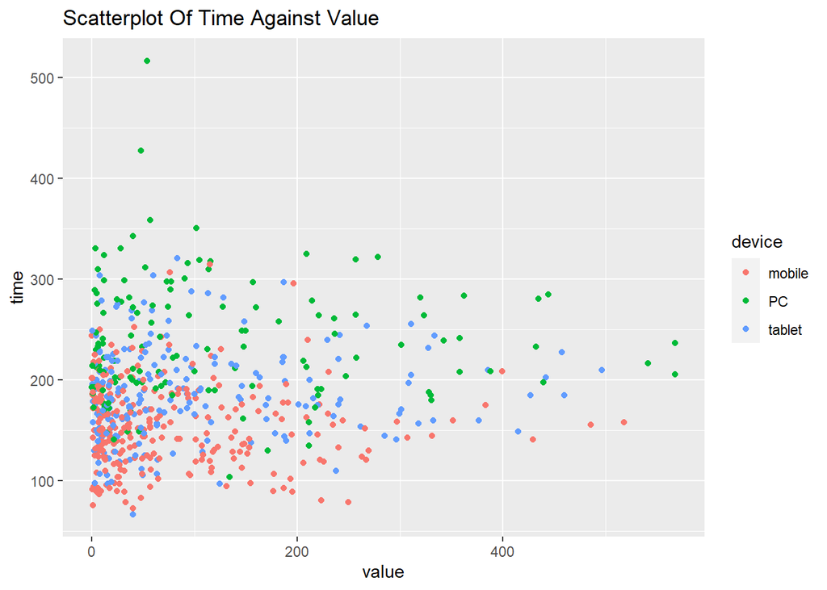

```r
scplot = ggplot(data = data, aes(x=value, y=time, fill=device, color=device))
scplot = scplot + geom_point() + labs(title = "Scatterplot Of Time Against Value")
scplot
```

#### Correlation of value and time.

```r
cor(data[c(5,6)])
```

```
##           value      time
## value 1.0000000 0.1008659
## time  0.1008659 1.0000000
```

```r
cat("Correlation of value and time using spearman method = ", cor(x=data$value, y=data$time, method = "spearman"))
```

```
## Correlation of value and time using spearman method =  0.108048
```

#### Comment critically on the dependence of time on value.

COMMENT: With a correlation of 0.1, both variables appear to have no (linear) relationship. Therefore, there is no dependence of time on value.

### 1.5

#### Stacked barplot of frequencies of device against status.

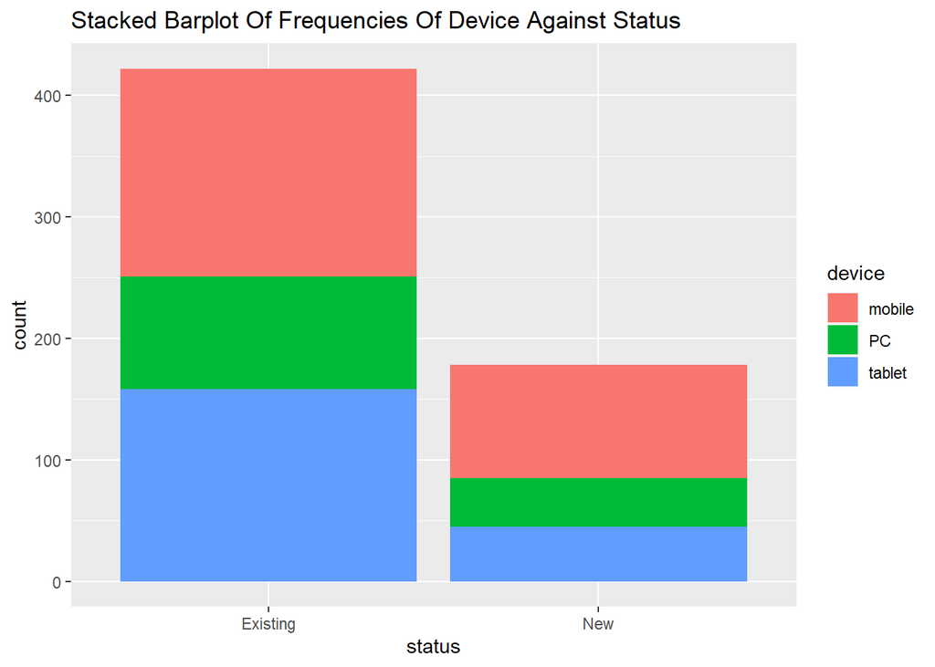

```r
sbplot = ggplot(data = data, aes(x=status, fill=device))
sbplot = sbplot + geom_bar(position="stack") + labs(title = "Stacked Barplot Of Frequencies Of Device Against Status")
sbplot
```

#### Stacked barplot of frequencies of status against device.

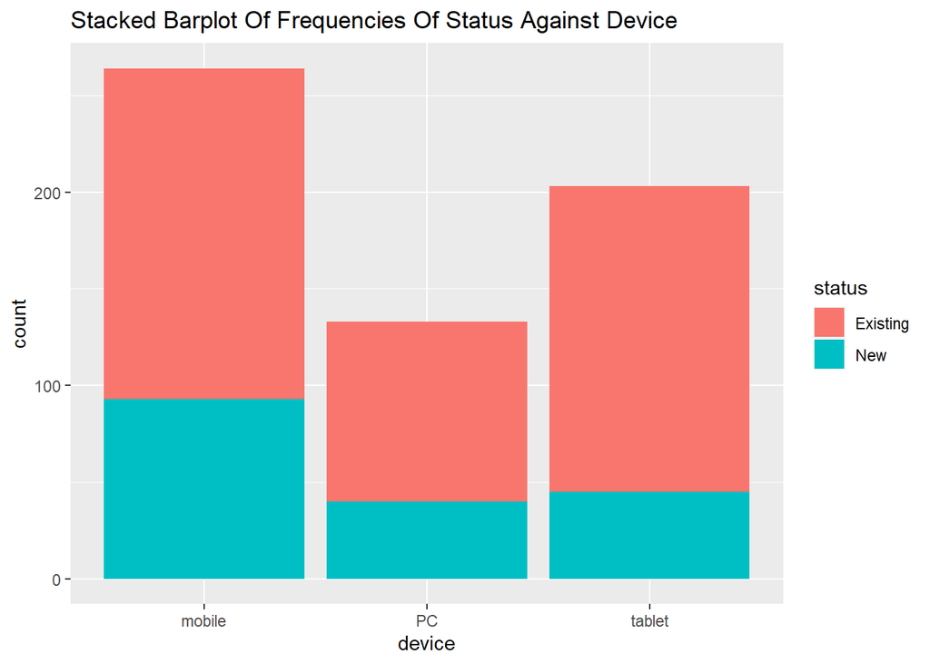

```r
sbplot2 = ggplot(data = data, aes(x=device, fill=status))
sbplot2 = sbplot2 + geom_bar(position="stack") + labs(title = "Stacked Barplot Of Frequencies Of Status Against Device")
sbplot2
```

#### Comment critically on the dependence of device and status.

COMMENT: The use of mobile and tablet devices appear to be higher for transactions executed by account holders to existing recipients than those executed to new recipients, while PC has the least number of transactions made to both new and existing recipients. Also, transactions by account holders to new recipients appear to be made more on mobile devices compared to PC and tablets.

## Section 2: Tables and Measures.

### 2.1

#### A one-way table of frequencies (counts), relative proportion and cumulative frequencies for recipient.

```r
t1 = table(data$recipient)
t1a = prop.table(t1)
t1b = cumsum(t1)

table1 = cbind(Frequencies = t1, Rel_proportion = round(t1a,2), Cummulative_Frequency = t1b)
table1
```

```
##          Frequencies Rel_proportion Cummulative_Frequency
## bill             147           0.24                   147
## purchase         308           0.51                   455
## self              52           0.09                   507
## transfer          93           0.16                   600
```

#### What are the most common, and what are the rarest recipient types?

The most common recipient type is ‘Purchase’. The rarest recipient type is ‘Self’.

### 2.2

#### A two-way table of recipient (in rows) and status (in columns) normalised to show the fraction of status for each recipient type.

```r
t2 = xtabs(~recipient+status, data=data)
table2 = round(prop.table(t2),2)
table2
```

```
##           status
## recipient  Existing  New
##   bill         0.20 0.04
##   purchase     0.30 0.21
##   self         0.08 0.01
##   transfer     0.12 0.03
```

#### Comment critically on any interesting observations.

COMMENT: Transactions made to Existing recipients for purchases make up the highest proportion (0.30) while transactions made to a new recipient account that belongs to the account holder makes up the lowest proportion (0.01).

### 2.3

#### A table showing the mean of model2 broken down by status.

```r
summarise(group_by(data, status), means = mean(model2))
```

```
## # A tibble: 2 x 2
##   status   means
##   <fct>    <dbl>
## 1 Existing  83.7
## 2 New       78.3
```

#### A table showing the mean of model2 broken down by device.

```r
summarise(group_by(data, device), means = mean(model2))
```

```
## # A tibble: 3 x 2
##   device means
##   <fct>  <dbl>
## 1 mobile  79.7
## 2 PC      84.6
## 3 tablet  83.5
```

## Section 3: Significance Tests.

### 3.1

#### Determining a 99% confidence interval for the mean value of model1.

```r
tt = t.test(data$model1, alternative = "two.sided", conf.level = 0.99)
tt
```

```
##
##  One Sample t-test
##
## data:  data$model1
## t = 453.11, df = 599, p-value < 2.2e-16
## alternative hypothesis: true mean is not equal to 0
## 99 percent confidence interval:
##  79.51758 80.42975
## sample estimates:
## mean of x
##  79.97367
```

The mean value of model1: 79.97367.

The 99% confidence interval for mean value of model1: 79.51758 - 80.42975.

#### Determining a 99% confidence interval for the mean value of model2.

```r
tt2 = t.test(data$model2, alternative = "two.sided", conf.level = 0.99)
tt2
```

```
##
##  One Sample t-test
##
## data:  data$model2
## t = 412.57, df = 599, p-value < 2.2e-16
## alternative hypothesis: true mean is not equal to 0
## 99 percent confidence interval:
##  81.55730 82.58537
## sample estimates:
## mean of x
##  82.07133
```

The mean value of model2: 82.07133.

The 99% confidence interval for mean value of model2: 81.5573 - 82.58537.

### 3.2

#### Paired two sample t-test to test for evidence of a difference in the performance of model2 compared to the performance of model1 across all the data, using a significance level of 0.05.

Defining the hypotheses for the paired t-test:  
H0 = The performances of model2 and model1 are the same.  
H1 = The performances of model2 and model1 are different.

```r
ptt = t.test(x=data$model2, y=data$model1, alternative = "two.sided", paired = T, mu = 0, sig.level = 0.05)
ptt
```

```
##
##  Paired t-test
##
## data:  data$model2 and data$model1
## t = 11.29, df = 599, p-value < 2.2e-16
## alternative hypothesis: true difference in means is not equal to 0
## 95 percent confidence interval:
##  1.732782 2.462552
## sample estimates:
## mean of the differences
##                2.097667
```

The p-value (2.2e-16) is less than 0.05 so we reject the NULL hypothesis and accept the alternative hypothesis. There is a significant difference in the performances of model2 and model1.

At 95% confidence level the mean performance of model2 is between 1.73 and 2.46 higher than the mean performance of model1.

#### T-test to assess the hypothesis that model2 outperforms model1 by a difference of 2, using a significance level of 0.05.

Defining the hypotheses for the paired t-test:  
H0 = Model2 outperforms model1 by a difference of 2.  
H1 = Model2 does not outperform model1 by a difference of 2.

```r
ptt2 = t.test(x=data$model2, y=data$model1, alternative = "greater", paired = T, mu = 2, sig.level = 0.05)
ptt2
```

```
##
##  Paired t-test
##
## data:  data$model2 and data$model1
## t = 0.52567, df = 599, p-value = 0.2997
## alternative hypothesis: true difference in means is greater than 2
## 95 percent confidence interval:
##  1.791591      Inf
## sample estimates:
## mean of the differences
##                2.097667
```

### 3.3

#### Non-parametric test to check for evidence of reduced performance of model2 on New recipients compared to Existing recipients, using a signifance level of 0.01.

Creating subsets of New and Existing recipients:

```r
NewRecipient = data$model2[data$status == 'New']
ExistingRecipient = data$model2[data$status == 'Existing']
```

Defining the hypotheses for the Wilcoxon rank sum test:  
H0 = There is no evidence of reduced performance of Model2 on New recipients compared to Existing Recipients.  
H1 = There is evidence of reduced performance of Model2 on New recipients compared to Existing Recipients.

```r
wt = wilcox.test(NewRecipient, ExistingRecipient, mu = 0, sig.level = 0.01, paired = F, exact = F, alternative = "less")
wt
```

```
##
##  Wilcoxon rank sum test with continuity correction
##
## data:  NewRecipient and ExistingRecipient
## W = 13316, p-value < 2.2e-16
## alternative hypothesis: true location shift is less than 0
```

Confirming with a Kruskal-wallis test

```r
kruskal.test(model2 ~ status, data = data)
```

```
##
##  Kruskal-Wallis rank sum test
##
## data:  model2 by status
## Kruskal-Wallis chi-squared = 156.22, df = 1, p-value < 2.2e-16
```

The p-value (2.2e-16) is less than 0.01, so we reject the Null hypothesis and accept the Alternative hypothesis. There is significant evidence of reduced performance of Model2 on New recipients compared to Existing Recipients.

#### Non-parametric test to check for a difference in performance of model2 for PC device compared to tablet device, using a signifance level of 0.01.

Creating subsets of PC and tablet devices:

```r
PC = data$model2[data$device == 'PC']
Tablet = data$model2[data$device == 'tablet']
```

Defining the hypotheses for the Wilcoxon rank sum test:  
H0 = The performance of Model2 for PC and Tablet Devices are the same.  
H1 = The performance of Model2 for PC and Tablet Devices are different.

```r
wt2 = wilcox.test(PC, Tablet, mu = 0, sig.level = 0.01, paired = F, exact = F, alternative = "two.sided")
wt2
```

```
##
##  Wilcoxon rank sum test with continuity correction
##
## data:  PC and Tablet
## W = 14867, p-value = 0.1164
## alternative hypothesis: true location shift is not equal to 0
```

The p-value (0.1164) is greater than 0.01, so there is no significant evidence to reject the NULL hypothesis. There is no significant difference in the performance of Model2 for PC and Tablet Devices.

### 3.4

#### One-way analysis of variance (ANOVA) to compare the model2 performance for the different types of recipient, using a significance level of 0.05.

Defining the hypotheses for the ANOVA test:  
H0: Model2 Performance is the same for all types of recipient.  
H1: Model2 Performance is different for at least 2 types of recipient.

```r
anova1 = aov(model2 ~ recipient, data = data)
summary(anova1)
```

```
##              Df Sum Sq Mean Sq F value Pr(>F)
## recipient     3   3676  1225.5   69.26 <2e-16 ***
## Residuals   596  10546    17.7
## ---
## Signif. codes:  0 '***' 0.001 '**' 0.01 '*' 0.05 '.' 0.1 ' ' 1
```

The p-value is less than 0.05, so we have to reject the null hypothesis and accept the alternative hypothesis. Model2 Performance is different for at least 2 types of recipient.

#### Tukey’s multiple comparisons to compare the model2 performance for the different types of recipient, using a confidence level of 0.95.

```r
tukey1 = TukeyHSD(anova1, conf.level = 0.95)
tukey1
```

```
##   Tukey multiple comparisons of means
##     95% family-wise confidence level
##
## Fit: aov(formula = model2 ~ recipient, data = data)
##
## $recipient
##                         diff       lwr         upr    p adj
## purchase-bill     -5.0766698 -6.163043 -3.99029680 0.000000
## self-bill         -0.7686028 -2.517134  0.97992873 0.669582
## transfer-bill     -6.3127716 -7.748634 -4.87690939 0.000000
## self-purchase      4.3080669  2.683336  5.93279804 0.000000
## transfer-purchase -1.2361018 -2.518322  0.04611844 0.063504
## transfer-self     -5.5441687 -7.420667 -3.66767063 0.000000
```

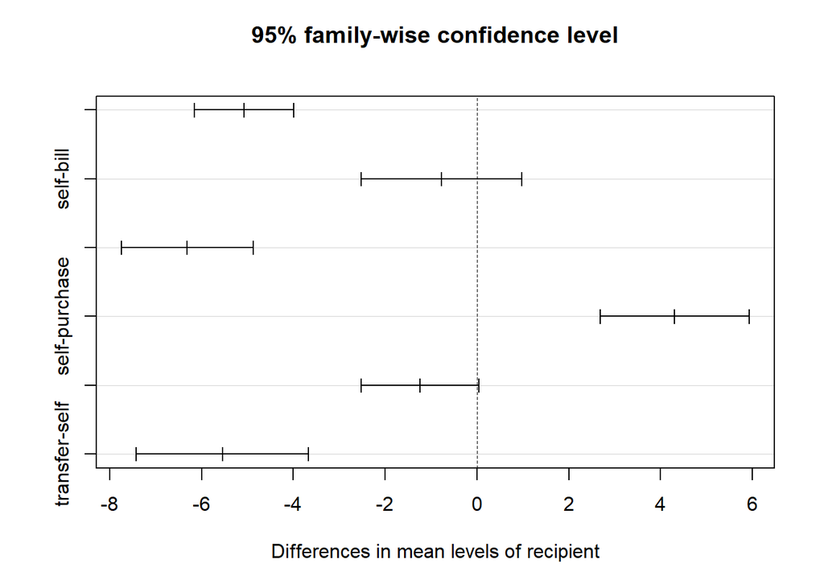

```r
plot(tukey1)
```

#### Checking the assumptions required for ANOVA and comment in the validity of the test.

For an ANOVA test to be valid, the residuals must be normally distributed.  
Checking distribution of residuals to know the validity of the ANOVA test:

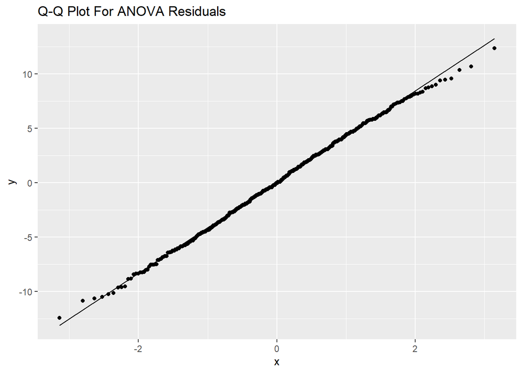

```r
#QQ plot of residuals
ResDf = data.frame(residuals = anova1$residuals)
ggplot(ResDf, aes(sample = residuals)) +
stat_qq() + stat_qq_line() + labs(title = "Q-Q Plot For ANOVA Residuals")
```

```r
#Shapiro-wilk test for normality of residuals
shapiro.test(anova1$residuals)
```

```
##
##  Shapiro-Wilk normality test
##
## data:  anova1$residuals
## W = 0.9984, p-value = 0.8662
```

COMMENT: From the point plot, it is observed that the residuals are normally distributed. The p-value from the Shapiro-wilk normality test further confirms the normality (p > 0.05). Hence, the ANOVA test is VALID!

## Section 4: Experiment Design, Sample Sizes and Random Sampling.

### 4.1

#### Calculating the standard deviation of model2

```r
stdev = sd(data$model2)
cat("Standard deviation of model2 = ", stdev)
```

```
## Standard deviation of model2 =  4.87267
```

### 4.2

#### Calculating the minimum sample size required to perform a 2-sample t-test of statistical power 0.9 for establishing a difference of 2 in performance if a two-sided test is to be performed with significance level 0.05 and the estimated standard deviation assumed to be the value calculated in task 4.1 above.

```r
pt1 = power.t.test(power = 0.9, delta = 2, sd = stdev, sig.level=0.05, type="two.sample", alternative = "two.sided")

pt1
```

```
##
##      Two-sample t test power calculation
##
##               n = 125.7066
##           delta = 2
##              sd = 4.87267
##       sig.level = 0.05
##           power = 0.9
##     alternative = two.sided
##
## NOTE: n is number in *each* group
```

```r
cat("The recommended sample size = ", ceiling(pt1$n))
```

```
## The recommended sample size =  126
```

#### How large a sample would be needed to increase the power of the test to 0.99 with significance level 0.01?

```r
pt2 = power.t.test(power = 0.99, delta = 2, sd = stdev, sig.level=0.01, type="two.sample", alternative = "two.sided")

pt2
```

```
##
##      Two-sample t test power calculation
##
##               n = 286.952
##           delta = 2
##              sd = 4.87267
##       sig.level = 0.01
##           power = 0.99
##     alternative = two.sided
##
## NOTE: n is number in *each* group
```

```r
cat("The recommended sample size = ", ceiling(pt2$n))
```

```
## The recommended sample size =  287
```

### 4.3

#### Let n be the first sample size calculated from 4.2 above. Create a data frame using a random sample of size n from transactions (with no duplicates).

```r
set.seed(59)
num = 126
randomSelection = slice_sample(data, n = num, replace = F)
randomSelection
```

```
##      id   status device recipient  value time model1 model2
## 1     3 Existing mobile      self 250.00   79   80.7   81.3
## 2   345      New     PC  purchase   2.47  193   78.2   77.9
## 3    39 Existing     PC  purchase   3.77  331   81.3   82.0
## 4   197      New mobile  purchase  24.51  169   74.2   78.6
## 5   205 Existing tablet      self 186.40  223   83.3   87.1
## 6   116 Existing mobile      bill 126.35  173   78.9   87.0
## 7     2      New tablet  transfer   0.88  196   81.1   76.7
## 8   331      New mobile  purchase   6.54  158   80.0   74.2
## 9    12 Existing mobile  transfer   1.33  172   66.2   78.8
## 10  391 Existing tablet      bill 215.44  182   88.1   90.5
## 11   30 Existing mobile      bill 114.97  120   83.8   91.1
## 12  322 Existing mobile  purchase 189.23  196   80.4   85.1
## 13  410 Existing tablet  purchase  79.25  127   81.3   83.9
## 14  522 Existing mobile      bill 331.54  145   82.1   88.8
```

[output cut: 112 more lines]

#### Comparing the distribution of the recipient values in the sample to the complete dataset.

```r
table3 = rbind(Complete = prop.table(table(data$recipient)),
               Random = prop.table(table(randomSelection$recipient)))
round(table3,2)
```

```
##          bill purchase self transfer
## Complete 0.24     0.51 0.09     0.16
## Random   0.27     0.52 0.09     0.12
```

The distribution of the bill and transfer recipient types in the randomly generated dataset are different from the complete dataset, while the distribution of the purchase and self recipient types are the same as the complete dataset.

### 4.4

#### Suppose that you had intended to create a stratified random sample that had occurrences of recipient in the (approximately) same proportion as the transactions dataset. Create a dataframe (with no duplicates) of size n with these properties and ensure that the sample is reproducible.

```r
set.seed(59)
GroupedDataset = group_by(data, recipient)
N = nrow(data)
StratifiedSelection = slice_sample(GroupedDataset, prop = num/N, replace = F)
print(StratifiedSelection, n = 126)
```

```
## # A tibble: 123 x 8
## # Groups:   recipient [4]
##        id status   device recipient  value  time model1 model2
##     <int> <fct>    <fct>  <fct>      <dbl> <int>  <dbl>  <dbl>
##   1    19 Existing mobile bill      131.      95   81     86.1
##   2   375 Existing tablet bill      296.     141   82.1   85.8
##   3   460 Existing PC     bill      224.     191   84     85
##   4   146 Existing tablet bill      188.     199   78.1   86.8
##   5   327 Existing tablet bill      220.     175   87.5   90.8
##   6   449 Existing PC     bill      212.     158   78.1   86.2
##   7   545 New      PC     bill       93.4    316   87.9   81.5
##   8   481 New      mobile bill       93.7    186   80.7   87.2
##   9    18 New      mobile bill      140.     171   81     80.8
##  10   304 Existing PC     bill       11.1    236   80.2   91
##  11    57 Existing PC     bill      134.     104   85.9   83.7
```

[output cut: 112 more lines]